# Notebook: Analyse Results of Trained Model

## Load Packages

```r
library(ggplot2)
library(dplyr)
library(tidyverse)
```

## Define Settings

```r
top_n <- 7
model_name <- "rf"
```

## Code

### Add Column

In order to better visualize the results of the trained model, I will add a column containing both year and month.

```r
evaluation_results <- read.csv(paste0("results/results_", model_name, ".csv"))

evaluation_results <- evaluation_results %>%
  mutate(year_month_train = paste(year_start_train, month_start_train, sep = "-"))

evaluation_results[, c("year_month_train", "Accuracy")]
```

```
##    year_month_train  Accuracy
## 1           2017-10 0.5981043
## 2           2017-11 0.6941020
## 3           2017-12 0.6021436
## 4            2018-1 0.7476816
## 5            2018-2 0.7435177
## 6            2018-3 0.5985756
## 7            2018-4 0.6838284
## 8            2018-5 0.7425840
## 9            2018-6 0.7366424
## 10           2018-7 0.7776460
## 11           2018-8 0.7735913
## 12           2018-9 0.7478372
## 13          2018-10 0.6774301
## 14          2018-11 0.7377691
```

[output cut: 53 more lines]

Compared to the other years, the classification accuracy for the months in 2020 is above 80% in most months and thus very high. Here, it should be noted that in 2020, the delay of departure for the flights that took off from Munich were rather low, which is why the upper class (above the median of the overall dataset) was rather rare in comparison to the lower class (below median of the overall dataset). See Notebook 03_dataset_exploration, which shows that the amount of delay was lower in 2020 comparing it with the amount of delay in the other years.

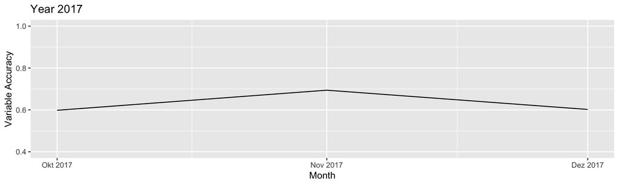

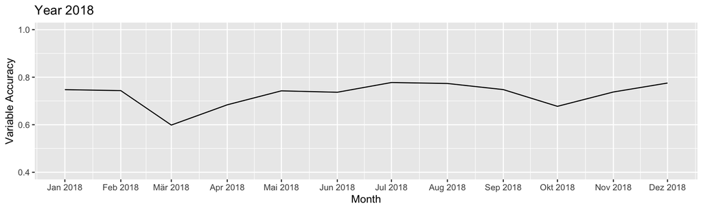

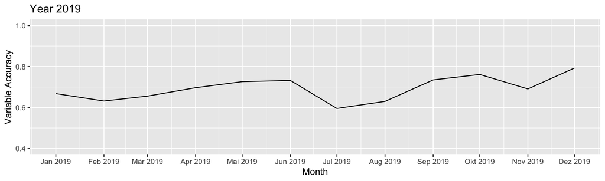

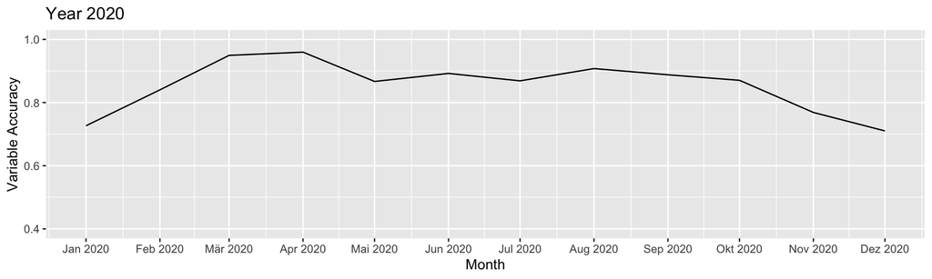

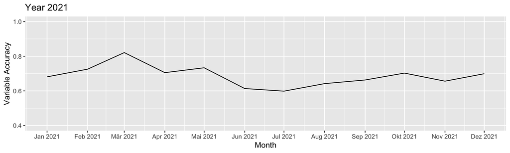

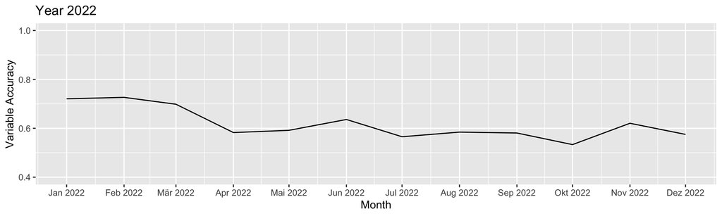

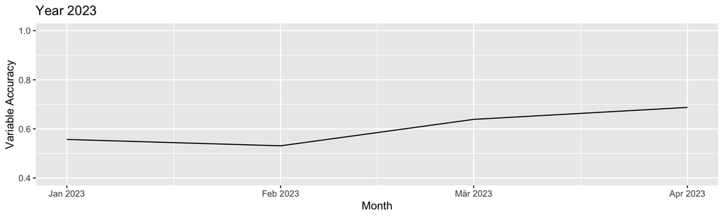

```r
# Date with day is required for visualisation, only year and month can't be transformed into a value of type Date
evaluation_results$year_month_train_first_day <- as.Date(paste0(evaluation_results$year_month_train, "-01"))
x_labels_months <- unique(evaluation_results$year_month_train_first_day)

for (year in unique(year(evaluation_results$year_month_train_first_day))) {
  year_data <- subset(evaluation_results, year(evaluation_results$year_month_train_first_day) == year)
  plot <- ggplot(year_data, aes(x = year_month_train_first_day, y = Accuracy)) +
    geom_line() +
    labs(x = "Month", y = "Variable Accuracy", color = "Feature") +
    scale_x_date(breaks = x_labels_months, labels = format(x_labels_months, "%b %Y")) +
    ggtitle(paste("Year", year)) +
    ylim(0.4, 1)
  print(plot)
}
```

### Calculate mean of each column

I want to calculate the mean of each metric based on all months for which I trained the model.

```r
metrics_df <- evaluation_results[, 6:23]

metrics <- data.frame(
  Mean = apply(metrics_df, 2, mean, na.rm = TRUE),
  Median = apply(metrics_df, 2, median, na.rm = TRUE),
  Min = apply(metrics_df, 2, min, na.rm = TRUE),
  Max = apply(metrics_df, 2, max, na.rm = TRUE),
  Q1 = apply(metrics_df, 2, quantile, probs = 0.25, na.rm = TRUE),
  Q3 = apply(metrics_df, 2, quantile, probs = 0.75, na.rm = TRUE)
)

row.names(metrics) <- colnames(metrics_df)
metrics
```

```
##                            Mean        Median           Min       Max
## Accuracy             0.70554407  6.991116e-01  5.310691e-01 0.9597315
## Kappa                0.09374519  6.766042e-02  0.000000e+00 0.3303331
## AccuracyLower        0.68777511  6.820479e-01  5.116350e-01 0.9371035
## AccuracyUpper        0.72266144  7.167382e-01  5.504329e-01 0.9759627
## AccuracyNull         0.69456731  6.990476e-01  5.126246e-01 0.9597315
## AccuracyPValue       0.30939340  2.176744e-01  4.391015e-19 1.0000000
## McnemarPValue        0.00615529 1.808694e-111 3.737605e-265 0.4123402
## Sensitivity          0.61035451  7.969925e-01  2.121212e-02 1.0000000
## Specificity          0.47309147  3.702738e-01  0.000000e+00 1.0000000
## Pos.Pred.Value       0.71644130  7.127883e-01  4.235294e-01 1.0000000
## Neg.Pred.Value       0.63340631  6.687457e-01  1.844660e-01 0.9375000
## Precision            0.71644130  7.127883e-01  4.235294e-01 1.0000000
## Recall               0.61035451  7.969925e-01  2.121212e-02 1.0000000
## F1                   0.57226370  6.080586e-01  4.154303e-02 0.9794521
## Prevalence           0.55416494  5.362421e-01  2.348058e-01 0.9597315
## Detection.Rate       0.41227305  3.434913e-01  6.990679e-03 0.9597315
## Detection.Prevalence 0.56483708  7.069225e-01  6.990679e-03 1.0000000
## Balanced.Accuracy    0.54172299  5.267963e-01  5.000000e-01 0.6486273
##                                 Q1           Q3
## Accuracy              6.307723e-01 7.477594e-01
## Kappa                 3.154250e-02 1.390147e-01
## AccuracyLower         6.132974e-01 7.313471e-01
## AccuracyUpper         6.479941e-01 7.636578e-01
## AccuracyNull          6.006163e-01 7.398903e-01
## AccuracyPValue        1.271031e-02 5.175630e-01
## McnemarPValue        1.167163e-163 2.514198e-51
## Sensitivity           1.996932e-01 9.861629e-01
## Specificity           3.805615e-02 9.322087e-01
## Pos.Pred.Value        6.174808e-01 8.243922e-01
## Neg.Pred.Value        5.603390e-01 7.299546e-01
## Precision             6.174808e-01 8.243922e-01
## Recall                1.996932e-01 9.861629e-01
## F1                    3.013986e-01 8.371245e-01
## Prevalence            3.566555e-01 7.224560e-01
## Detection.Rate        6.835340e-02 7.056321e-01
## Detection.Prevalence  1.022413e-01 9.799708e-01
## Balanced.Accuracy     5.108425e-01 5.666108e-01
```

### Get Most Important Features

Now, I want to select the features with the highest average variable importance. First of all, I select the columns with the features and it’s variable importance scores.

```r
feature_columns <- evaluation_results[, 24:ncol(evaluation_results)]
head(feature_columns[, 1:3])
```

```
##   X.airline_nameATRAN.AviatransCargoAirlines.
## 1                                    14.91165
## 2                                    29.23680
## 3                                    31.83495
## 4                                    47.35090
## 5                                    55.92527
## 6                                    54.68931
##   X.airline_nameArkia.IsraeliAirlines. X.airline_nameCzechAirlines.CSA..
## 1                             11.58341                          11.58341
## 2                             20.02685                          20.02685
## 3                             21.36193                          21.36193
## 4                             22.44039                          22.44039
## 5                             14.19916                          14.19916
## 6                             19.12725                          19.12725
```

```r
column_means <- sapply(feature_columns, mean)
sorted_means <- sort(column_means, decreasing = TRUE)
top_n_columns <- names(sorted_means)[1:top_n]
head(top_n_columns)
```

```
## [1] "year_month_train_first_day"        "departure_scheduled_hour_local"
## [3] "departure_scheduled_weekday_local" "temperature_celsius_low"
## [5] "baro"                              "temperature_celsius"
```

### Format Data for Visualisation of the Development of the Feature Importance Over Time

```r
selected_feature_timeseries <- evaluation_results %>%
  select(all_of(top_n_columns), year_month_train_first_day)
selected_feature_timeseries <- tidyr::gather(selected_feature_timeseries, key = "feature", value = "importance", -year_month_train_first_day)
head(selected_feature_timeseries)
```

```
##   year_month_train_first_day                        feature importance
## 1                 2017-10-01 departure_scheduled_hour_local   66.09383
## 2                 2017-11-01 departure_scheduled_hour_local   77.81628
## 3                 2017-12-01 departure_scheduled_hour_local  100.00000
## 4                 2018-01-01 departure_scheduled_hour_local   82.00490
## 5                 2018-02-01 departure_scheduled_hour_local   72.73728
## 6                 2018-03-01 departure_scheduled_hour_local   72.24412
```

### Create Visualisation for each Year

To visualize the development of the feature importance over time, I for each year and month a dataframe (`year_data`) with three columns is created.

Columns:

- the month and year of the test data that should be evaluated
- the name of the feature
- the importance of the feature.

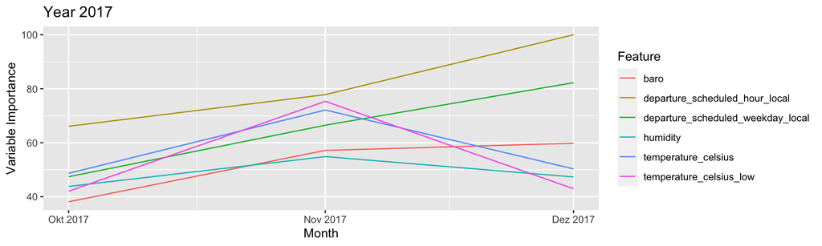

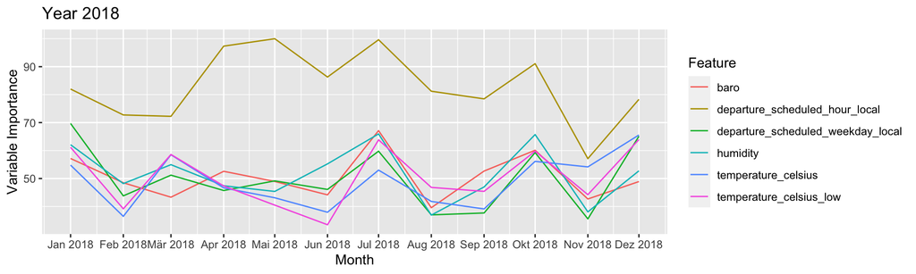

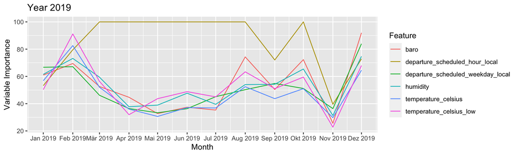

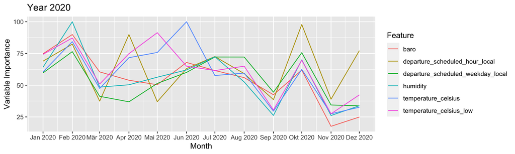

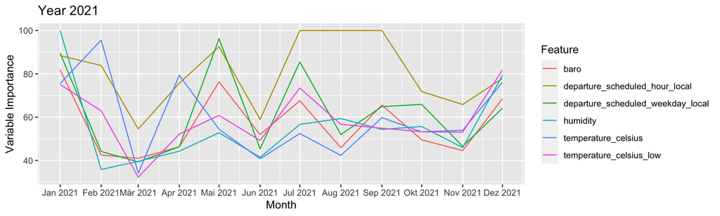

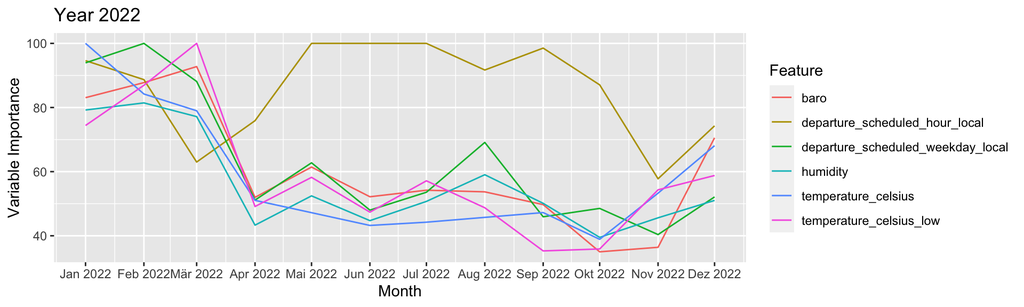

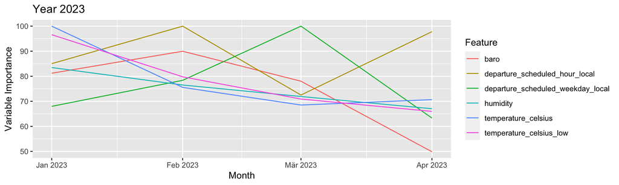

```r
for (year in unique(year(selected_feature_timeseries$year_month_train_first_day))) {
  year_data <- subset(selected_feature_timeseries, year(selected_feature_timeseries$year_month_train_first_day) == year)
  plot <- ggplot(year_data, aes(x = year_month_train_first_day, y = importance, color = feature)) +
    geom_line() +
    labs(x = "Month", y = "Variable Importance", color = "Feature") +
    scale_x_date(breaks = x_labels_months, labels = format(x_labels_months, "%b %Y")) +
    ggtitle(paste("Year", year))

  filename <- paste0("plots/", "plot_", model_name, "_", year, ".png", sep = "")
  ggsave(filename, plot = plot, width = 20, height = 10, dpi = 300)
  print(plot)
}
```